# Practical Machine Learning Prediction Assignment Write up

Kyle Day

January 13, 2016

In this project we will use data from accelerometers on the belt, forearm, arm, and dumbell of 6 participants. They were asked to perform barbell lifts correctly and incorrectly in 5 different ways.We are presented with a training data set with just under 20,000 observations of 160 variables and there classifications from A to E. We were also giving a set of 20 observations with no classifications. The goal is to create a model which is able to correctly predict the outcome of these 20 observations.

More details on the data set here: http://groupware.les.inf.puc-rio.br/har

### Set working directory

```r
setwd("C:/R_Projects/MachLearn")
```

### Packages needed

```r
library(caret)
```

### Loading Data

```r
finaltest <- read.csv("pml-testing.csv", header=T, na.strings=c("NA", "#DIV/0!", ""))

training <- read.csv("pml-training.csv", header=T, na.strings=c("NA", "#DIV/0!", ""))
```

After the first load it is clear that we need to treat both blanks and “#DIV/0!” as NA

### Slicing our data

The first thing we need to do is split our data. We already have a separate testing set.However we will still split the training set and then use the original testing set as a little bit of extra validation.

We will use set.seed to make sure our model is created off of the same subset of training data if we run this process multiple times. Failure to do this will cause your subtrain and subtest data sets to vary and there for will give you a different model if you were to repeat this process.

```r
set.seed(1111)

inTrain <- createDataPartition(y = training$classe, p = 0.6, list = F)

subtrain <- training[inTrain, ]

subtest <- training[-inTrain, ]
```

We will need to redo everything done to the subtrain to the subtest and like wise to the final testing set which we will use at the end for extra validation. It may be tempting to preform these modifications to all sets at the same time or before splitting, but this might lead to over fitting as you adjust your models from visual inspections along the way. Splitting now is the correct way to do it to avoid any influence the test set might have on training our model.

### Inspecting the Data

We see from “summary(subtrain)” that many of the variables are mostly NA values.We need to remove these variables. Had there been one variable which held a meaningful number of records we would need to consider whether to include it. For the data we have here those with “NA’s” are almost entirely “NA” and there for will provide little insight.

```r
#summary(subtrain)
subtrain <- subtrain[, colSums(is.na(subtrain)) == 0]

ncol(subtrain)
```

```
## [1] 60
```

We now have 60 variables to consider.

#### Removing Non-variable Covariates

After looking at our new list we see that the first 7 will not provide meaningful insight.We will also look to see if any of the remainder lack variation.

```r
subtrain <- subtrain[ , 8:(ncol(subtrain))]

nsv <- nearZeroVar(subtrain, saveMetrics = T)

nsv
```

```
##                      freqRatio percentUnique zeroVar   nzv
## roll_belt             1.060550    8.58525815   FALSE FALSE
## pitch_belt            1.168224   13.63790761   FALSE FALSE
## yaw_belt              1.212014   14.49558424   FALSE FALSE
## total_accel_belt      1.078257    0.23777174   FALSE FALSE
## gyros_belt_x          1.071602    1.06148098   FALSE FALSE
## gyros_belt_y          1.141243    0.56046196   FALSE FALSE
## gyros_belt_z          1.023674    1.36718750   FALSE FALSE
## accel_belt_x          1.109170    1.35020380   FALSE FALSE
## accel_belt_y          1.208473    1.16338315   FALSE FALSE
## accel_belt_z          1.101852    2.42866848   FALSE FALSE
## magnet_belt_x         1.023041    2.52207880   FALSE FALSE
## magnet_belt_y         1.167979    2.37771739   FALSE FALSE
## magnet_belt_z         1.039146    3.61752717   FALSE FALSE
## roll_arm             48.900000   19.42085598   FALSE FALSE
## pitch_arm            67.482759   22.41847826   FALSE FALSE
## yaw_arm              31.548387   21.66270380   FALSE FALSE
## total_accel_arm       1.000000    0.54347826   FALSE FALSE
## gyros_arm_x           1.023333    5.33288043   FALSE FALSE
## gyros_arm_y           1.450479    3.08254076   FALSE FALSE
## gyros_arm_z           1.072555    1.97860054   FALSE FALSE
## accel_arm_x           1.039216    6.45380435   FALSE FALSE
## accel_arm_y           1.195652    4.42425272   FALSE FALSE
## accel_arm_z           1.181818    6.41134511   FALSE FALSE
## magnet_arm_x          1.037736   11.12432065   FALSE FALSE
## magnet_arm_y          1.018868    7.21807065   FALSE FALSE
## magnet_arm_z          1.014925   10.54687500   FALSE FALSE
## roll_dumbbell         1.024691   87.47452446   FALSE FALSE
## pitch_dumbbell        2.493976   85.19870924   FALSE FALSE
## yaw_dumbbell          1.037500   87.16032609   FALSE FALSE
## total_accel_dumbbell  1.087952    0.34816576   FALSE FALSE
## gyros_dumbbell_x      1.035422    1.98709239   FALSE FALSE
## gyros_dumbbell_y      1.211538    2.23335598   FALSE FALSE
## gyros_dumbbell_z      1.025773    1.60495924   FALSE FALSE
## accel_dumbbell_x      1.040201    3.40523098   FALSE FALSE
## accel_dumbbell_y      1.135135    3.86379076   FALSE FALSE
## accel_dumbbell_z      1.223022    3.35427989   FALSE FALSE
## magnet_dumbbell_x     1.090909    8.87398098   FALSE FALSE
## magnet_dumbbell_y     1.039683    6.85292120   FALSE FALSE
## magnet_dumbbell_z     1.096491    5.57065217   FALSE FALSE
## roll_forearm         11.690000   14.95414402   FALSE FALSE
## pitch_forearm        54.372093   21.03430707   FALSE FALSE
## yaw_forearm          16.574468   14.12194293   FALSE FALSE
## total_accel_forearm   1.238827    0.55197011   FALSE FALSE
## gyros_forearm_x       1.042763    2.36073370   FALSE FALSE
## gyros_forearm_y       1.030568    6.05468750   FALSE FALSE
## gyros_forearm_z       1.114187    2.42017663   FALSE FALSE
## accel_forearm_x       1.076923    6.56419837   FALSE FALSE
## accel_forearm_y       1.064516    8.21161685   FALSE FALSE
## accel_forearm_z       1.089888    4.62805707   FALSE FALSE
## magnet_forearm_x      1.020408   12.04144022   FALSE FALSE
## magnet_forearm_y      1.283019   15.37873641   FALSE FALSE
## magnet_forearm_z      1.048780   13.44259511   FALSE FALSE
## classe                1.469065    0.04245924   FALSE FALSE
```

All of the remaining variables are variable.

### Creating Our Model(s)

#### RF

As most of you probably discovered, if you fail to use a control then the boot strapping used by default tends to take forever and a day.

```r
set.seed(1111)

trcontrol <- trainControl(allowParallel=T, method = "cv", number = 5)
modelfit <- train(classe ~ ., data=subtrain, model = "rf", trControl = trcontrol)
```

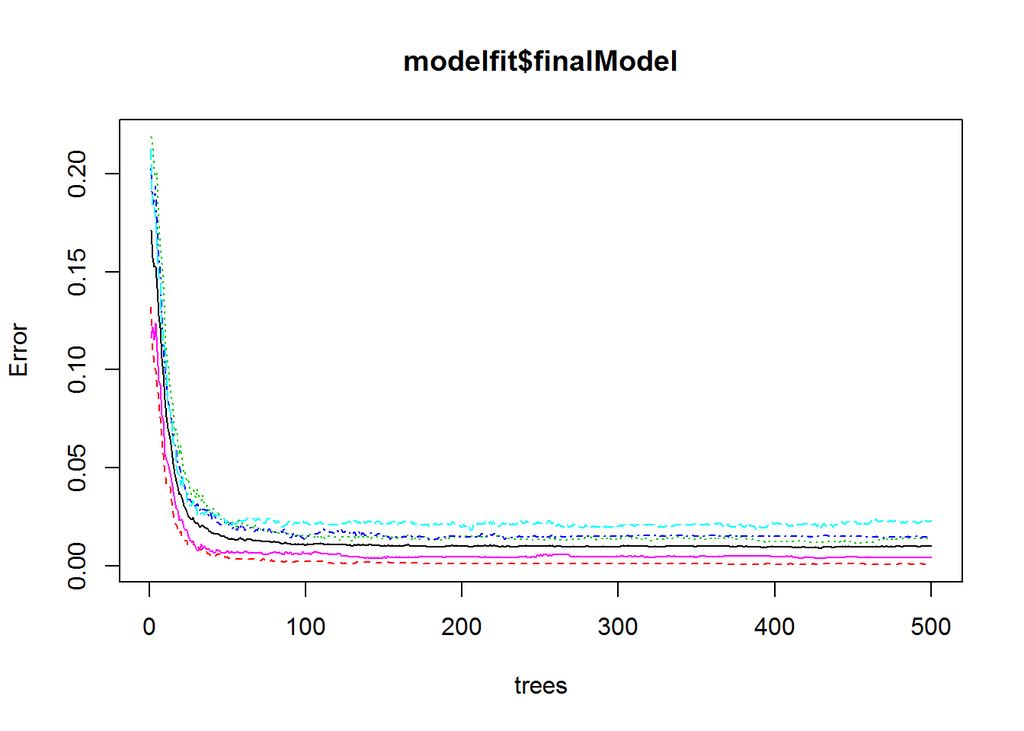

```r
plot(modelfit$finalModel)
```

```r
print(modelfit$finalModel)
```

```
##
## Call:
##  randomForest(x = x, y = y, mtry = param$mtry, model = "rf")
##                Type of random forest: classification
##                      Number of trees: 500
## No. of variables tried at each split: 2
##
##         OOB estimate of  error rate: 1.02%
## Confusion matrix:
##      A    B    C    D    E  class.error
## A 3345    2    1    0    0 0.0008960573
## B   22 2247   10    0    0 0.0140412462
## C    0   28 2023    3    0 0.0150925024
## D    0    0   44 1885    1 0.0233160622
## E    0    0    3    6 2156 0.0041570439
```

```r
modelfit
```

```
## Random Forest
##
## 11776 samples
##    52 predictor
##     5 classes: 'A', 'B', 'C', 'D', 'E'
##
## No pre-processing
## Resampling: Cross-Validated (5 fold)
## Summary of sample sizes: 9421, 9420, 9420, 9422, 9421
## Resampling results across tuning parameters:
##
##   mtry  Accuracy   Kappa      Accuracy SD  Kappa SD
##    2    0.9878569  0.9846378  0.002091039  0.002644419
##   27    0.9876874  0.9844232  0.002416977  0.003057797
##   52    0.9809784  0.9759364  0.002821335  0.003570266
##
## Accuracy was used to select the optimal model using  the largest value.
## The final value used for the model was mtry = 2.
```

```r
#varImpPlot(modelfit$finalModel)

#getTree(modelfit$finalModel, k=23)
```

```r
set.seed(1111)

modelfit2 <- train(classe ~ ., data=subtrain, model = "rpart", trControl = trcontrol)

print(modelfit2$finalModel)
```

```
##
## Call:
##  randomForest(x = x, y = y, mtry = param$mtry, model = "rpart")
##                Type of random forest: classification
##                      Number of trees: 500
## No. of variables tried at each split: 2
##
##         OOB estimate of  error rate: 1.02%
## Confusion matrix:
##      A    B    C    D    E  class.error
## A 3345    2    1    0    0 0.0008960573
## B   22 2247   10    0    0 0.0140412462
## C    0   28 2023    3    0 0.0150925024
## D    0    0   44 1885    1 0.0233160622
## E    0    0    3    6 2156 0.0041570439
```

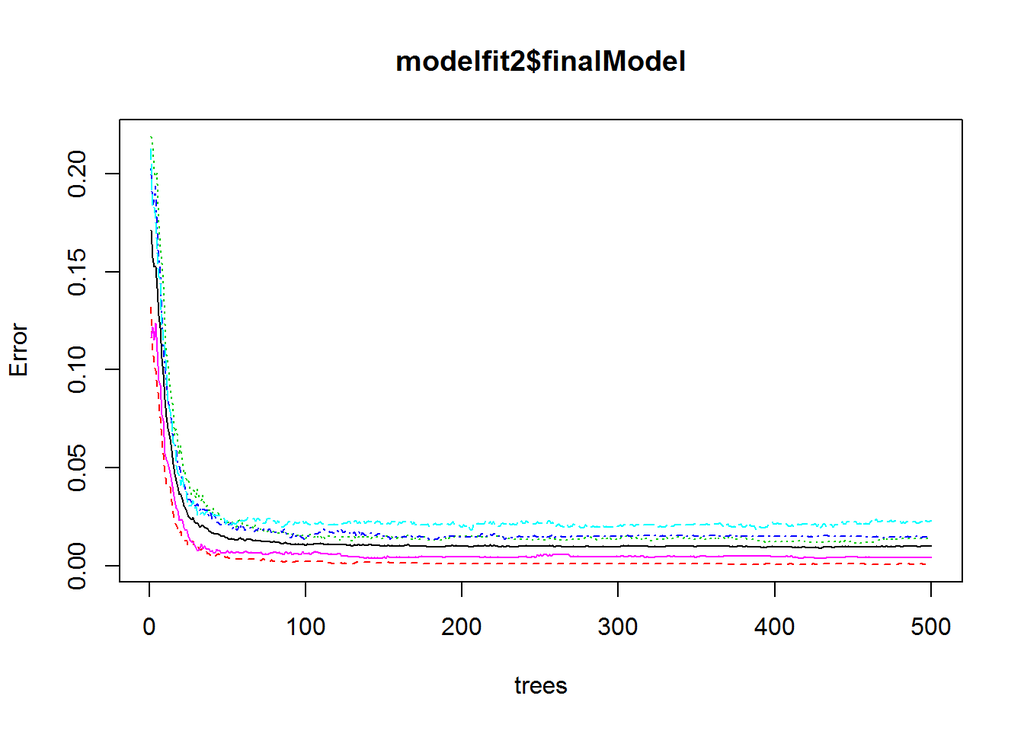

```r
plot(modelfit2$finalModel)
```

```r
modelfit2
```

```
## Random Forest
##
## 11776 samples
##    52 predictor
##     5 classes: 'A', 'B', 'C', 'D', 'E'
##
## No pre-processing
## Resampling: Cross-Validated (5 fold)
## Summary of sample sizes: 9421, 9420, 9420, 9422, 9421
## Resampling results across tuning parameters:
##
##   mtry  Accuracy   Kappa      Accuracy SD  Kappa SD
##    2    0.9878569  0.9846378  0.002091039  0.002644419
##   27    0.9876874  0.9844232  0.002416977  0.003057797
##   52    0.9809784  0.9759364  0.002821335  0.003570266
##
## Accuracy was used to select the optimal model using  the largest value.
## The final value used for the model was mtry = 2.
```

#### Model Choice

“rf” OOB estimate of error rate: 1.02%

It is important that we look at these **estimated** out of sample error rates to determine which to use. If we were to measure the actual out of sample error rate using our subtest data set to make our choice then we would be unable to get an accurate measure of our out of sample error rate later. This would be because we used a result from the (sub)test set to make our model choice and our actual test set is only 20 observations, not enough for an accurate out of sample error rate.

### Evaluating our Model

We need to first format our subtest to the same format as our subtrain.

```r
subtest <- subtest[, colSums(is.na(subtest)) == 0]

#ncol(subtest) #summary(subtest)
#This makes the assumption that the columns with NA's in the train also
# are the column with NA's in the test. Here that holds.

subtest <- subtest[ , 8:(ncol(subtest))]
```

Next we see how our model does.

```r
outcome <- predict(modelfit, newdata=subtest)

cm <- confusionMatrix(subtest$classe, outcome)
cm
```

```
## Confusion Matrix and Statistics
##
##           Reference
## Prediction    A    B    C    D    E
##          A 2232    0    0    0    0
##          B   10 1500    8    0    0
##          C    0    9 1356    3    0
##          D    0    0   30 1255    1
##          E    0    0    2    3 1437
##
## Overall Statistics
##
##                Accuracy : 0.9916
##                  95% CI : (0.9893, 0.9935)
##     No Information Rate : 0.2858
##     P-Value [Acc > NIR] : < 2.2e-16
##
##                   Kappa : 0.9894
##  Mcnemar's Test P-Value : NA
##
## Statistics by Class:
##
##                      Class: A Class: B Class: C Class: D Class: E
## Sensitivity            0.9955   0.9940   0.9713   0.9952   0.9993
## Specificity            1.0000   0.9972   0.9981   0.9953   0.9992
## Pos Pred Value         1.0000   0.9881   0.9912   0.9759   0.9965
## Neg Pred Value         0.9982   0.9986   0.9938   0.9991   0.9998
## Prevalence             0.2858   0.1923   0.1779   0.1607   0.1833
## Detection Rate         0.2845   0.1912   0.1728   0.1600   0.1832
## Detection Prevalence   0.2845   0.1935   0.1744   0.1639   0.1838
## Balanced Accuracy      0.9978   0.9956   0.9847   0.9953   0.9993
```

```r
outcomeacc <- sum(outcome == subtest$classe) / length(outcome) *100
#gives us our accuracy, although it was shown above in cm
```

99.158807 accuracy is what we expected and isn’t bad.

### Predict 20 Observation test set

```r
finaltest <- finaltest[, colSums(is.na(finaltest)) == 0]

#ncol(finaltest) #summary(finaltest)
#This makes the assumption that the columns with NA's in the train also
# are the column with NA's in the test. Here that holds.

finaltest <- finaltest[ , 8:(ncol(finaltest))]

testoutcome <- predict(modelfit, newdata = finaltest)
testoutcome
```

```
##  [1] B A B A A E D B A A B C B A E E A B B B
## Levels: A B C D E
```

Data for this project comes from:

Velloso, E.; Bulling, A.; Gellersen, H.; Ugulino, W.; Fuks, H. Qualitative Activity Recognition of Weight Lifting Exercises. Proceedings of 4th International Conference in Cooperation with SIGCHI (Augmented Human ’13) . Stuttgart, Germany: ACM SIGCHI, 2013.

Read more: http://groupware.les.inf.puc-rio.br/har#ixzz3xGsCqX5w